# Carseats

**Índice**  
1. Chapter 3 - Exercise 10

# Chapter 3 - Exercise 10

This question should be answered using the Carseats data set.

```r
library(ISLR2)
help(Carseats)
```

```r
attach(Carseats)
```

A simulated data set containing sales of child car seats at 400 different stores.  
A data frame with 400 observations on the following 11 variables.  
+ ‘Sales’ Unit sales (in thousands) at each location  
+ ‘CompPrice’ Price charged by competitor at each location  
+ ‘Income’ Community income level (in thousands of dollars)  
+ ‘Advertising’ Local advertising budget for company at each location (in thousands of dollars)  
+ ‘Population’ Population size in region (in thousands)  
+ ‘Price’ Price company charges for car seats at each site  
+ ‘ShelveLoc’ A factor with levels ‘Bad’, ‘Good’ and ‘Medium’ indicating the quality of the shelving location for the car seats at each site  
+ ‘Age’ Average age of the local population  
+ ‘Education’ Education level at each location  
+ ‘Urban’ A factor with levels ‘No’ and ‘Yes’ to indicate whether the store is in an urban or rural location  
+ ‘US’ A factor with levels ‘No’ and ‘Yes’ to indicate whether the store is in the US or not

1. Fit a multiple regression model to predict Sales using Price, Urban, and US.

```r
A=lm(Sales~Price+Urban+US,data=Carseats)
summary(A)
```

```
Call:
lm(formula = Sales ~ Price + Urban + US, data = Carseats)

Residuals:
    Min      1Q  Median      3Q     Max
-6.9206 -1.6220 -0.0564  1.5786  7.0581

Coefficients:
             Estimate Std. Error t value Pr(>|t|)
(Intercept) 13.043469   0.651012  20.036  < 2e-16 ***
Price       -0.054459   0.005242 -10.389  < 2e-16 ***
UrbanYes    -0.021916   0.271650  -0.081    0.936
USYes        1.200573   0.259042   4.635 4.86e-06 ***
---
Signif. codes:  0 ‘***’ 0.001 ‘**’ 0.01 ‘*’ 0.05 ‘.’ 0.1 ‘ ’ 1

Residual standard error: 2.472 on 396 degrees of freedom
Multiple R-squared:  0.2393,    Adjusted R-squared:  0.2335
F-statistic: 41.52 on 3 and 396 DF,  p-value: < 2.2e-16
```

2. Provide an interpretation of each coefficient in the model. Be careful, some of the variables in the model are qualitative!

Intercept: the sales with Urban=No and US=No, al margen del precio.  
Price: increment (negative)-0.054459 of sales for a one unit increment in price.  
UrbanYes: variation of sales (neg.) if the store is in an urban location.  
USYes: increment of sales if the store is in the US

3. Write out the model in equation form, being careful to handle the qualitative variables properly.

4. For which of the predictors can you reject the null hypothesis H_0 : β j = 0?

For Price and USYes because their p-values are low.

5. On the basis of your response to the previous question, fit a smaller model that only uses the predictors for which there is evidence of association with the outcome.

```r
B=lm(Sales~Price+US,data=Carseats)
summary(B)
```

```
Call:
lm(formula = Sales ~ Price + US, data = Carseats)

Residuals:
    Min      1Q  Median      3Q     Max
-6.9269 -1.6286 -0.0574  1.5766  7.0515

Coefficients:
            Estimate Std. Error t value Pr(>|t|)
(Intercept) 13.03079    0.63098  20.652  < 2e-16 ***
Price       -0.05448    0.00523 -10.416  < 2e-16 ***
USYes        1.19964    0.25846   4.641 4.71e-06 ***
---
Signif. codes:  0 ‘***’ 0.001 ‘**’ 0.01 ‘*’ 0.05 ‘.’ 0.1 ‘ ’ 1

Residual standard error: 2.469 on 397 degrees of freedom
Multiple R-squared:  0.2393,    Adjusted R-squared:  0.2354
F-statistic: 62.43 on 2 and 397 DF,  p-value: < 2.2e-16
```

6. How well do the models in (a) and (e) fit the data?

It is practically the same RSE, R². Adjusted R² is better for the second model. It is better to have less variables. Adjusted R² penalizes excess of variables.

7. Using the model from (e), obtain 95 % confidence intervals for the coefficient(s).

```r
confint(B)
```

```
                  2.5 %      97.5 %
(Intercept) 11.79032020 14.27126531
Price       -0.06475984 -0.04419543
USYes        0.69151957  1.70776632
```

8. Is there evidence of outliers or high leverage observations in the model from (e)?

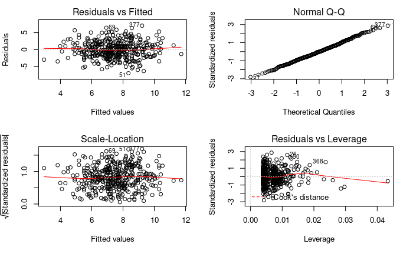

```r
par(mfrow = c(2,2))
plot(B)
```